# Notes

Jeswin

1 October 2017

```r
# loading libraries
library(ggplot2)
library(tidyr)
suppressMessages(library(dplyr))
suppressMessages(library(gridExtra))
suppressMessages(library(gcookbook))
# laoding data
data("mtcars")
data("cabbage_exp")
summary(mtcars)
```

```
##       mpg             cyl             disp             hp
##  Min.   :10.40   Min.   :4.000   Min.   : 71.1   Min.   : 52.0
##  1st Qu.:15.43   1st Qu.:4.000   1st Qu.:120.8   1st Qu.: 96.5
##  Median :19.20   Median :6.000   Median :196.3   Median :123.0
##  Mean   :20.09   Mean   :6.188   Mean   :230.7   Mean   :146.7
##  3rd Qu.:22.80   3rd Qu.:8.000   3rd Qu.:326.0   3rd Qu.:180.0
##  Max.   :33.90   Max.   :8.000   Max.   :472.0   Max.   :335.0
##       drat             wt             qsec             vs
##  Min.   :2.760   Min.   :1.513   Min.   :14.50   Min.   :0.0000
##  1st Qu.:3.080   1st Qu.:2.581   1st Qu.:16.89   1st Qu.:0.0000
##  Median :3.695   Median :3.325   Median :17.71   Median :0.0000
##  Mean   :3.597   Mean   :3.217   Mean   :17.85   Mean   :0.4375
##  3rd Qu.:3.920   3rd Qu.:3.610   3rd Qu.:18.90   3rd Qu.:1.0000
##  Max.   :4.930   Max.   :5.424   Max.   :22.90   Max.   :1.0000
##        am              gear            carb
##  Min.   :0.0000   Min.   :3.000   Min.   :1.000
##  1st Qu.:0.0000   1st Qu.:3.000   1st Qu.:2.000
##  Median :0.0000   Median :4.000   Median :2.000
##  Mean   :0.4062   Mean   :3.688   Mean   :2.812
##  3rd Qu.:1.0000   3rd Qu.:4.000   3rd Qu.:4.000
##  Max.   :1.0000   Max.   :5.000   Max.   :8.000
```

```r
str(mtcars)
```

```
## 'data.frame':    32 obs. of  11 variables:
##  $ mpg : num  21 21 22.8 21.4 18.7 18.1 14.3 24.4 22.8 19.2 ...
##  $ cyl : num  6 6 4 6 8 6 8 4 4 6 ...
##  $ disp: num  160 160 108 258 360 ...
##  $ hp  : num  110 110 93 110 175 105 245 62 95 123 ...
##  $ drat: num  3.9 3.9 3.85 3.08 3.15 2.76 3.21 3.69 3.92 3.92 ...
##  $ wt  : num  2.62 2.88 2.32 3.21 3.44 ...
##  $ qsec: num  16.5 17 18.6 19.4 17 ...
##  $ vs  : num  0 0 1 1 0 1 0 1 1 1 ...
##  $ am  : num  1 1 1 0 0 0 0 0 0 0 ...
##  $ gear: num  4 4 4 3 3 3 3 4 4 4 ...
##  $ carb: num  4 4 1 1 2 1 4 2 2 4 ...
```

```r
str(cabbage_exp)
```

```
## 'data.frame':    6 obs. of  6 variables:
##  $ Cultivar: Factor w/ 2 levels "c39","c52": 1 1 1 2 2 2
##  $ Date    : Factor w/ 3 levels "d16","d20","d21": 1 2 3 1 2 3
##  $ Weight  : num  3.18 2.8 2.74 2.26 3.11 1.47
##  $ sd      : num  0.957 0.279 0.983 0.445 0.791 ...
##  $ n       : int  10 10 10 10 10 10
##  $ se      : num  0.3025 0.0882 0.311 0.1408 0.2501 ...
```

# Mapping Variables to Colors

**to use a variable (column from a data frame) to control the color of geoms.**

Observe here **geom_col()** was used instead of geom_bar()

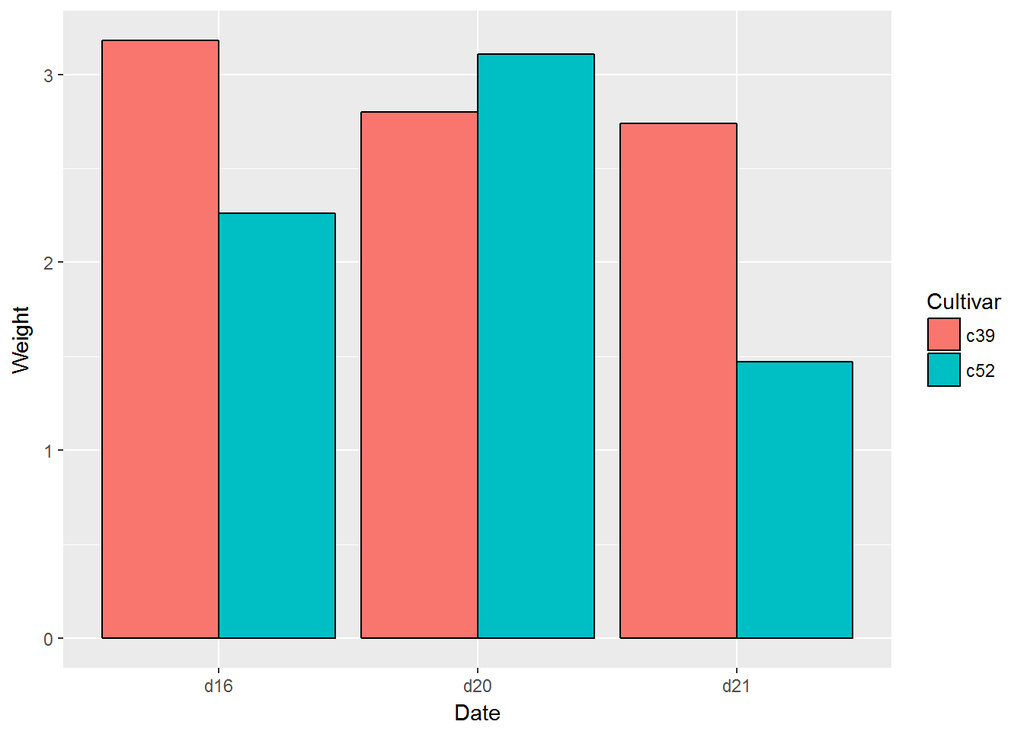

```r
ggplot(data = cabbage_exp, aes(x=Date, y=Weight))+
  geom_col(aes(fill=Cultivar), color = 'black', position = 'dodge')
```

In the cabbage_exp example, the variable Cultivar is mapped to fill. The Cultivar column in cabbage_exp is a factor, so ggplot2 treats it as a discrete variable.

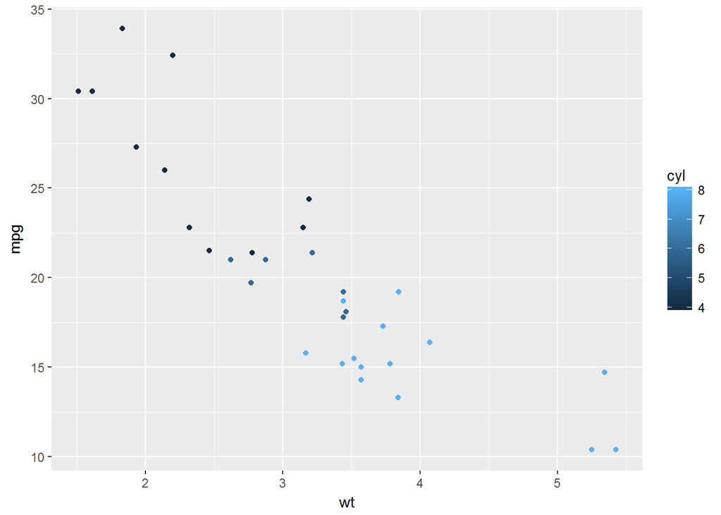

```r
ggplot(data = mtcars, aes(x=wt, y = mpg))+
  geom_point(aes(color = cyl))
```

In the mtcars example, cyl is numeric, so it is treated as a continuous variable. Because of this, even though the actual values of cyl include only 4, 6, and 8, the legend has entries for the intermediate values 5 and 7.

To make ggplot() treat cyl as a categorical variable, you can convert it to a factor in the call to ggplot(), or you can modify the data so that the column is a character vector or factor

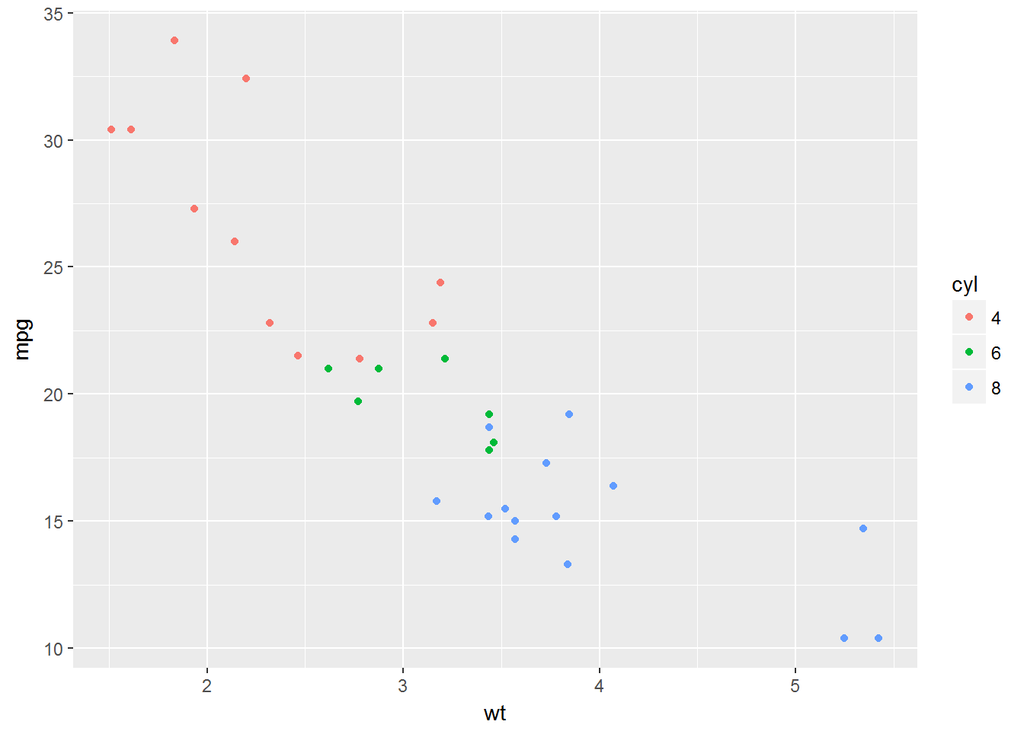

```r
mtcars$cyl <- factor(mtcars$cyl)  # Converted that column as a facor variable: check using str

ggplot(data = mtcars, aes(x=wt, y = mpg))+
  geom_point(aes(color = cyl))
```

# Using a Different Palette for a Discrete Variable

to use different colors for a discrete mapped variable.

```r
data('uspopage') # Age distribution of population in the United States, 1900-2002
summary(uspopage)
```

```
##       Year         AgeGroup     Thousands
##  Min.   :1900   <5     :103   Min.   : 3099
##  1st Qu.:1925   5-14   :103   1st Qu.:13557
##  Median :1951   15-24  :103   Median :19759
##  Mean   :1951   25-34  :103   Mean   :20900
##  3rd Qu.:1977   35-44  :103   3rd Qu.:24411
##  Max.   :2002   45-54  :103   Max.   :45154
##                 (Other):206
```

```r
str(uspopage)
```

```
## 'data.frame':    824 obs. of  3 variables:
##  $ Year     : int  1900 1900 1900 1900 1900 1900 1900 1900 1901 1901 ...
##  $ AgeGroup : Factor w/ 8 levels "<5","5-14","15-24",..: 1 2 3 4 5 6 7 8 1 2 ...
##  $ Thousands: int  9181 16966 14951 12161 9273 6437 4026 3099 9336 17158 ...
```

#### here we’ll use the default palette (hue)

**scale_fill_hue() and scale_colour_hue() : Colors evenly spaced around the color wheel (same as discrete)**

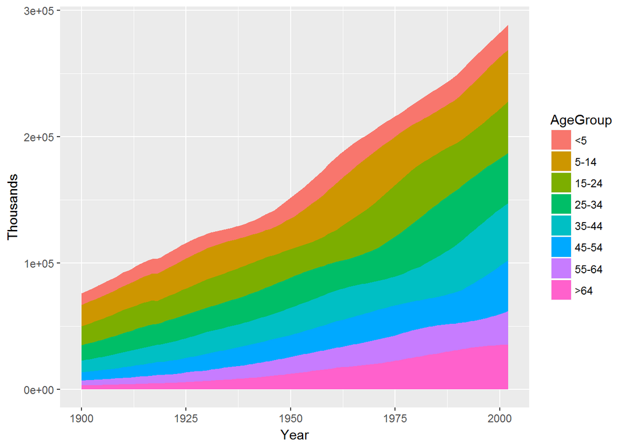

[output not shown]

```r
p <- ggplot(data = uspopage, aes(x=Year, y=Thousands, fill = AgeGroup)) + geom_area()
p
```

Using a ColorBrewer palette

#### scale_fill_brewer() scale_colour_brewer() ColorBrewer palettes

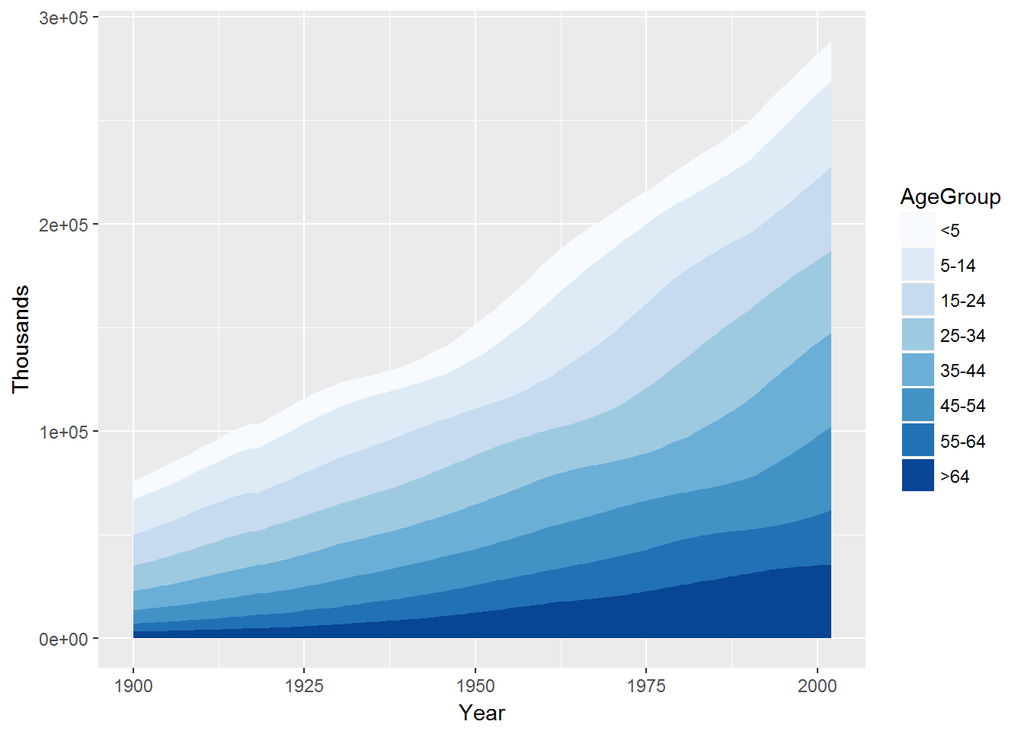

```r
p + scale_fill_brewer()
```

- Changing a palette is a modification of the color (or fill) scale: it involves a change in the mapping from numeric or categorical values to aesthetic attributes.
- There are two types of scales that use colors: **fill** scales and **color** scales.

With **scale_fill_hue()**, the colors are taken from around the color wheel in the HCL (hue-chroma-lightness) color space. The default lightness value is 65 on a scale from 0-100. This is good for filled areas, but it’s a bit light for points and lines.

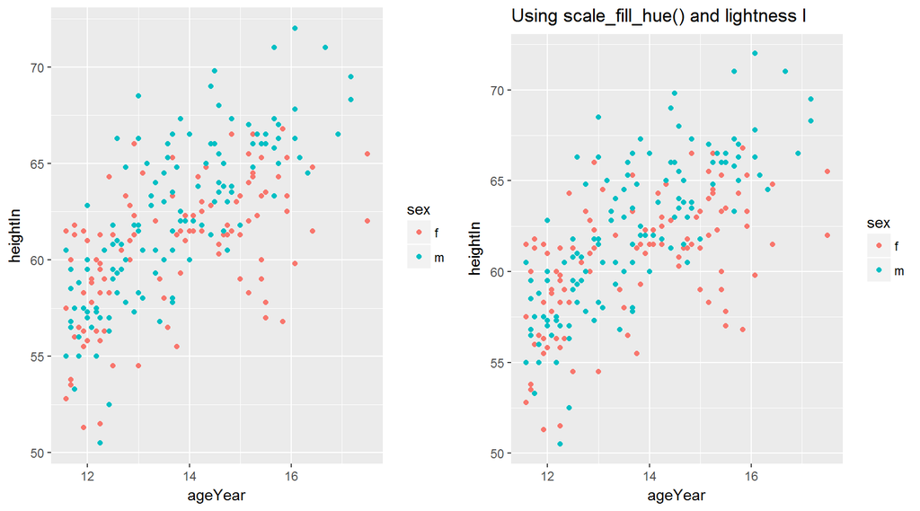

```r
data('heightweight')
#summary(heightweight)

h <- ggplot(data = heightweight, aes(x=ageYear, y=heightIn, color = sex))+
  geom_point()

h2 <- h + scale_fill_hue(l = 45)+
  labs(title = 'Using scale_fill_hue() and lightness l')

grid.arrange(h,h2,ncol=2)
```

#### scale_fill_brewer doesnt run when loading the below library

```
library(RColorBrewer)
display.brewer.all()
```

ColorBrewer palettes can be selected by name. For example, this will use the Oranges palette :

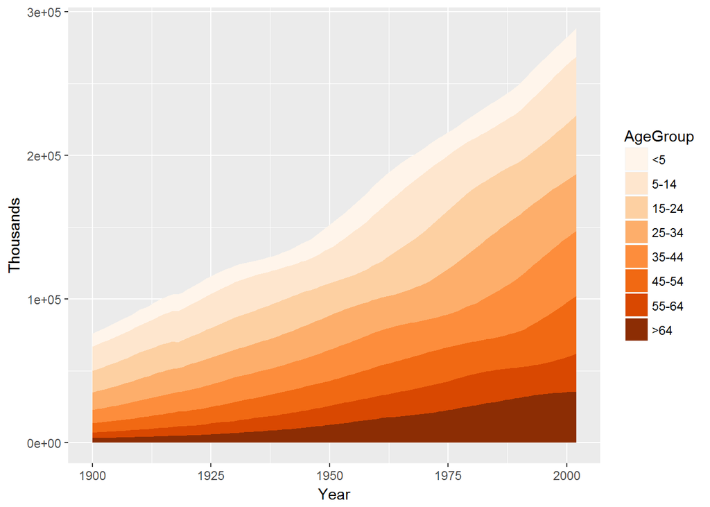

```r
p + scale_fill_brewer(palette="Oranges")
```

You can also use a **palette of greys**. This is useful for print when the output is in black and white. The default is to start at 0.2 and end at 0.8, on a scale from 0 (black) to 1 (white), but you can change the range

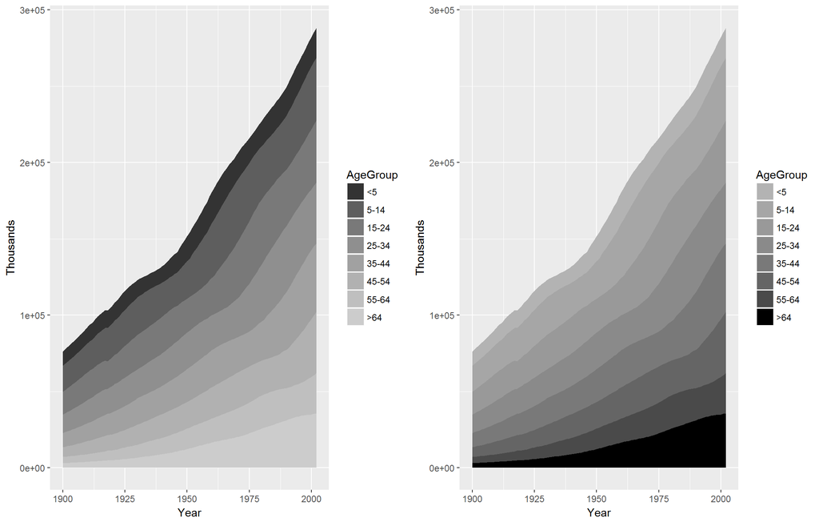

```r
g1 <- p + scale_fill_grey()
g2 <- p + scale_fill_grey(start=0.7, end=0)

grid.arrange(g1,g2,ncol=2)
```

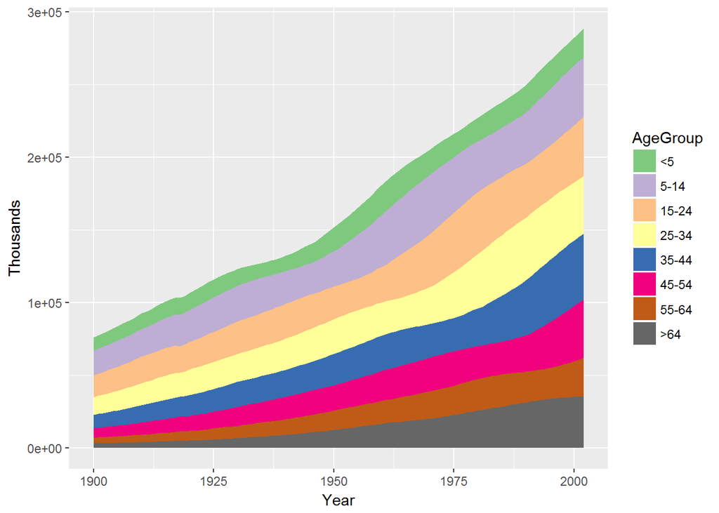

```r
p + scale_fill_brewer(type = 'qual')
```

So if type = ‘qual’ not given the function automatically creates a graph with same color but light intensity decreasing with the ordfer of the factor